# 第六次习题课

Hanchao Yan

2025-03-12

# 使用大模型做逻辑回归

使用[**豆包**](https://www.doubao.com/)，可以点击[**此链接**](https://www.doubao.com/thread/w3013086c8d114502)获取完整对话历史

## 第一轮：描述统计——基本描述

**输入PROMPT**：你是一名专业的数据科学家，我是零代码基础的用户。我将提供给你一份CSV格式的数据集（文件名：第3章.csv），请你读取数据，并输出以下信息：（1）简要介绍数据；（2）告知变量个数与样本量；（3）每一列的计算样本均值、样本标准差、中位数、最小值、最大值。

**输出结果**：我将读取数据集，简要介绍数据，告知变量个数与样本量，并且计算每一列的样本均值、样本标准差、中位数、最小值和最大值。

```
数据基本信息：
<class 'pandas.core.frame.DataFrame'>
RangeIndex: 684 entries, 0 to 683
Data columns (total 8 columns):
 #   Column  Non-Null Count  Dtype
---  ------  --------------  -----
 0   ARA     684 non-null    float64
 1   ASSET   684 non-null    float64
 2   ATO     684 non-null    float64
 3   ROA     684 non-null    float64
 4   GROWTH  684 non-null    float64
 5   LEV     684 non-null    float64
 6   SHARE   684 non-null    float64
 7   ST      684 non-null    int64
dtypes: float64(7), int64(1)
memory usage: 42.9 KB
数据前几行内容信息：
    ARA ASSET   ATO ROA GROWTH  LEV SHARE   ST
0   0.192309634 19.85604835 0.0052  0.087709802 -0.950727316    0.445880057 26.89   0
1   0.220119957 20.91086312 0.0056  0.016820383 -0.942656324    0.398686374 39.62   0
2   0.325291689 19.35262341 0.0166  0.042468332 -0.937440417    0.303348107 26.46   0
3   0.025728678 21.43892774 0.0028  0.01815163  -0.852995319    0.758250185 60.16   0
4   0.533590893 21.61333919 0.2552  0.004146607 -0.816703929    0.726875299 54.24   1
```

接下来我将从以下几个方面详细介绍这份数据集：

1. **数据总体概述**：此数据集包含 684 行，8 列，推测参与分析的字段及其含义如下：
   - `ARA`：可能代表某种比率相关的指标，数据类型为 float64。
   - `ASSET`：可能代表资产相关数值，数据类型为 float64。
   - `ATO`：可能是某种周转率相关指标，数据类型为 float64。
   - `ROA`：可能是资产回报率相关指标，数据类型为 float64。
   - `GROWTH`：可能代表增长率相关数值，数据类型为 float64。
   - `LEV`：可能代表杠杆率相关指标，数据类型为 float64。
   - `SHARE`：可能代表股份或占比相关数值，数据类型为 float64。
   - `ST`：可能是一个分类标识，数据类型为 int64。
2. **变量个数与样本量**：变量个数为 8 个，样本量为 684 个。
3. **各列统计信息**：计算每一列的样本均值、样本标准差、中位数、最小值和最大值。

```
             mean        std     median        min        max
ARA      0.095049   0.092289   0.068327   0.000000   0.634684
ASSET   20.777853   0.833523  20.700503  18.660700  24.017611
ATO      0.519774   0.362826   0.433400   0.002800   3.151300
ROA      0.055870   0.038594   0.051258   0.000082   0.311130
GROWTH   0.115257   0.307020   0.102283  -0.950727   0.998557
LEV      0.406064   0.165764   0.406740   0.018431   0.980322
SHARE   46.034518  17.684377  44.955000   4.160000  88.580000
ST       0.052632   0.223460   0.000000   0.000000   1.000000
```

以下是各列的样本均值、样本标准差、中位数、最小值和最大值的统计结果：

| Column | Mean | Std | Median | Min | Max |
| --- | --- | --- | --- | --- | --- |
| ARA | 0.095049 | 0.092289 | 0.068327 | 0.000000 | 0.634684 |
| ASSET | 20.777853 | 0.833523 | 20.700503 | 18.660700 | 24.017611 |
| ATO | 0.519774 | 0.362826 | 0.433400 | 0.002800 | 3.151300 |
| ROA | 0.055870 | 0.038594 | 0.051258 | 0.000082 | 0.311130 |
| GROWTH | 0.115257 | 0.307020 | 0.102283 | -0.950727 | 0.998557 |
| LEV | 0.406064 | 0.165764 | 0.406740 | 0.018431 | 0.980322 |
| SHARE | 46.034518 | 17.684377 | 44.955000 | 4.160000 | 88.580000 |
| ST | 0.052632 | 0.223460 | 0.000000 | 0.000000 | 1.000000 |

### 各指标统计结果分析

1. **ARA**：均值为 0.095049，标准差 0.092289，说明数据相对较为分散。中位数 0.068327 略低于均值，最小值为 0，最大值 0.634684，表明该指标数值分布可能右偏。
2. **ASSET**：均值 20.777853，标准差 0.833523，数据相对集中。中位数 20.700503 与均值接近，取值范围在 18.660700 到 24.017611 之间，整体波动较小。
3. **ATO**：均值 0.519774，标准差 0.362826，数据有一定的离散程度。中位数 0.433400 低于均值，最小值 0.002800 到最大值 3.151300 的范围较大，可能存在少数较大值影响整体分布。
4. **ROA**：均值 0.055870，标准差 0.038594，数据相对集中。中位数 0.051258 略低于均值，取值在 0.000082 到 0.311130 之间，分布较为紧凑。
5. **GROWTH**：均值 0.115257，标准差 0.307020，离散程度较大。中位数 0.102283 接近均值，最小值 -0.950727 到最大值 0.998557，说明该指标的波动范围很广。
6. **LEV**：均值 0.406064，标准差 0.165764，数据相对集中。中位数 0.406740 与均值接近，取值在 0.018431 到 0.980322 之间，分布较为稳定。
7. **SHARE**：均值 46.034518，标准差 17.684377，数据离散程度较高。中位数 44.955000 接近均值，取值范围从 4.160000 到 88.580000，波动幅度很大。
8. **ST**：均值 0.052632，标准差 0.223460，由于其取值只有 0 和 1，中位数为 0，说明大部分取值为 0，只有少部分为 1。

## 第二轮：描述统计——变量描述

**输入PROMPT**：看上去这是一份金融数据。假设ST是因变量，剩下的是自变量。请你绘制各个自变量的直方图，并做简要分析。

**输出结果**：我将绘制各个自变量的直方图，以便直观展示其数据分布情况。

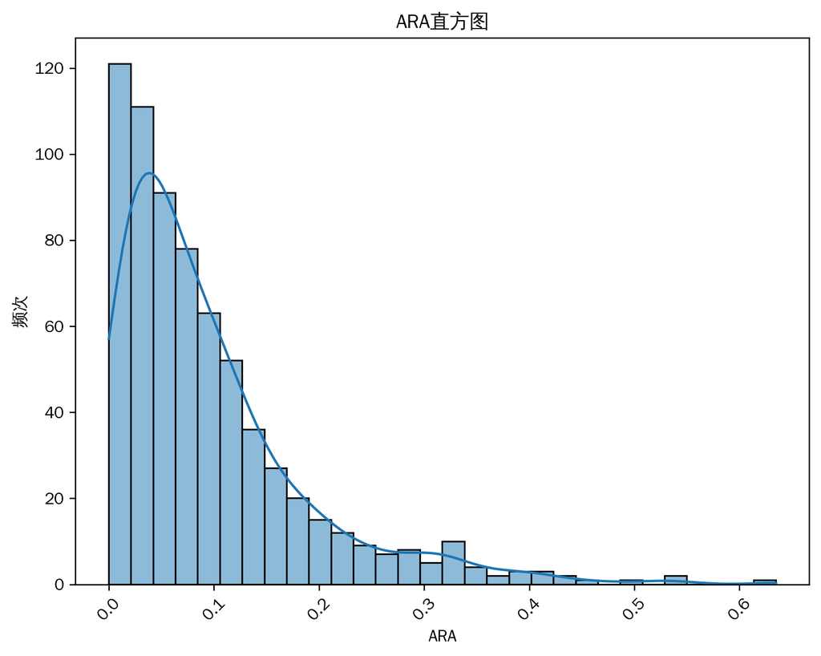

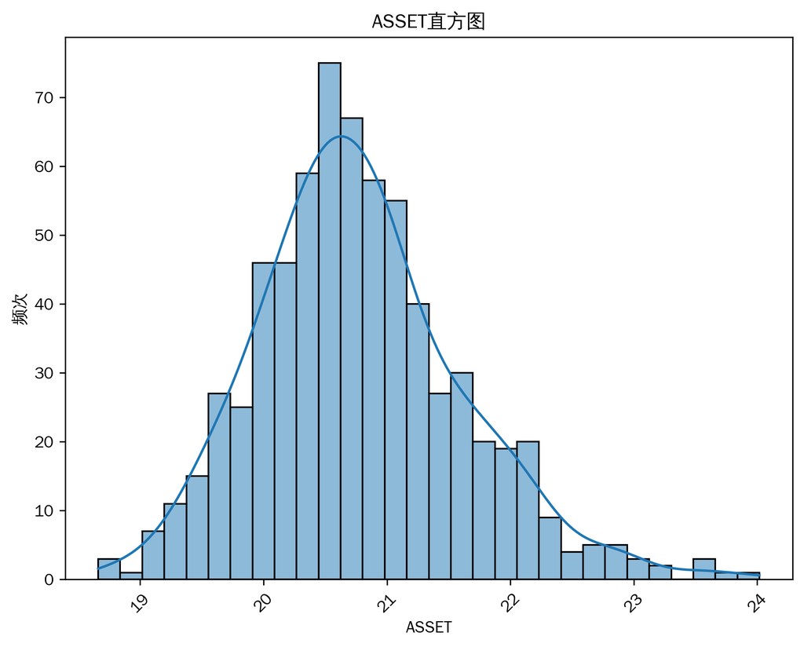

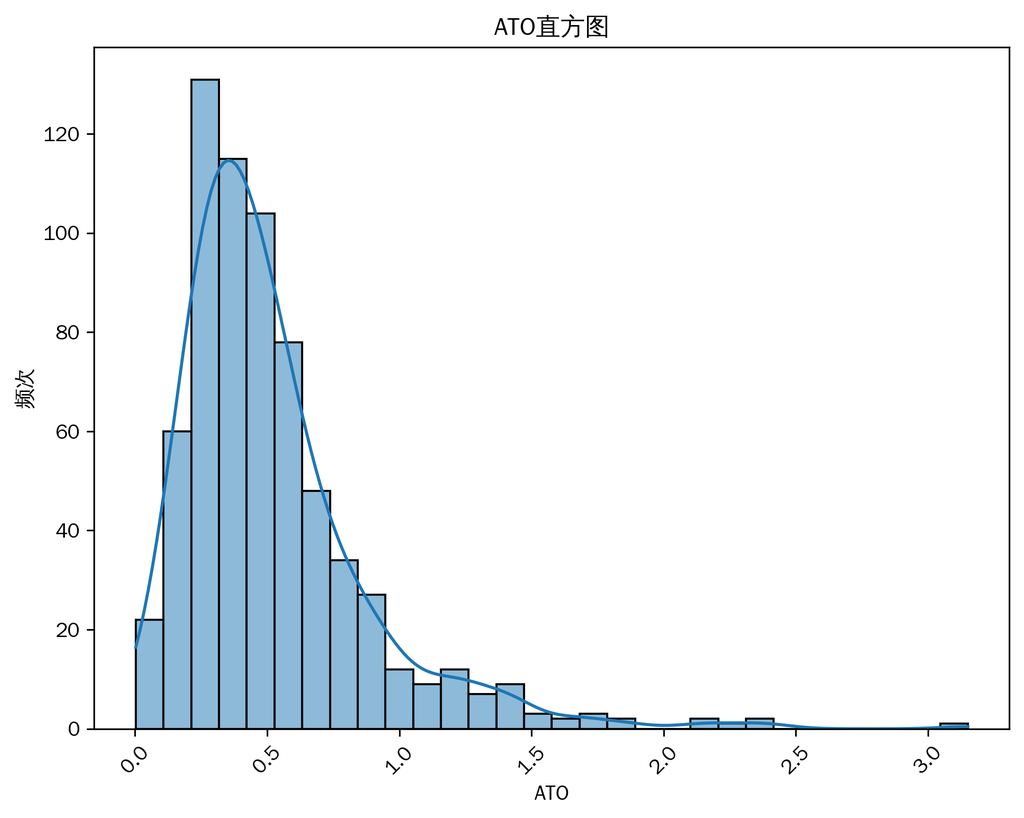

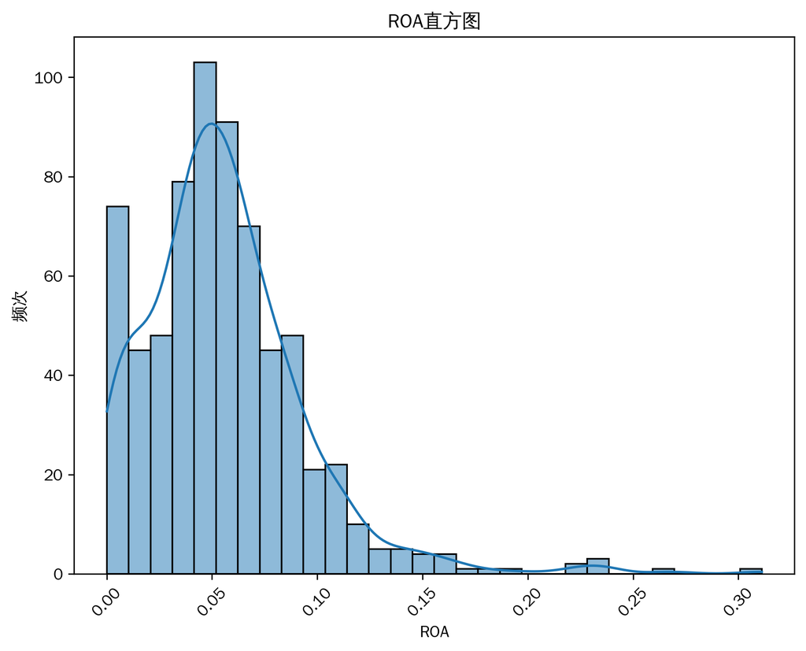

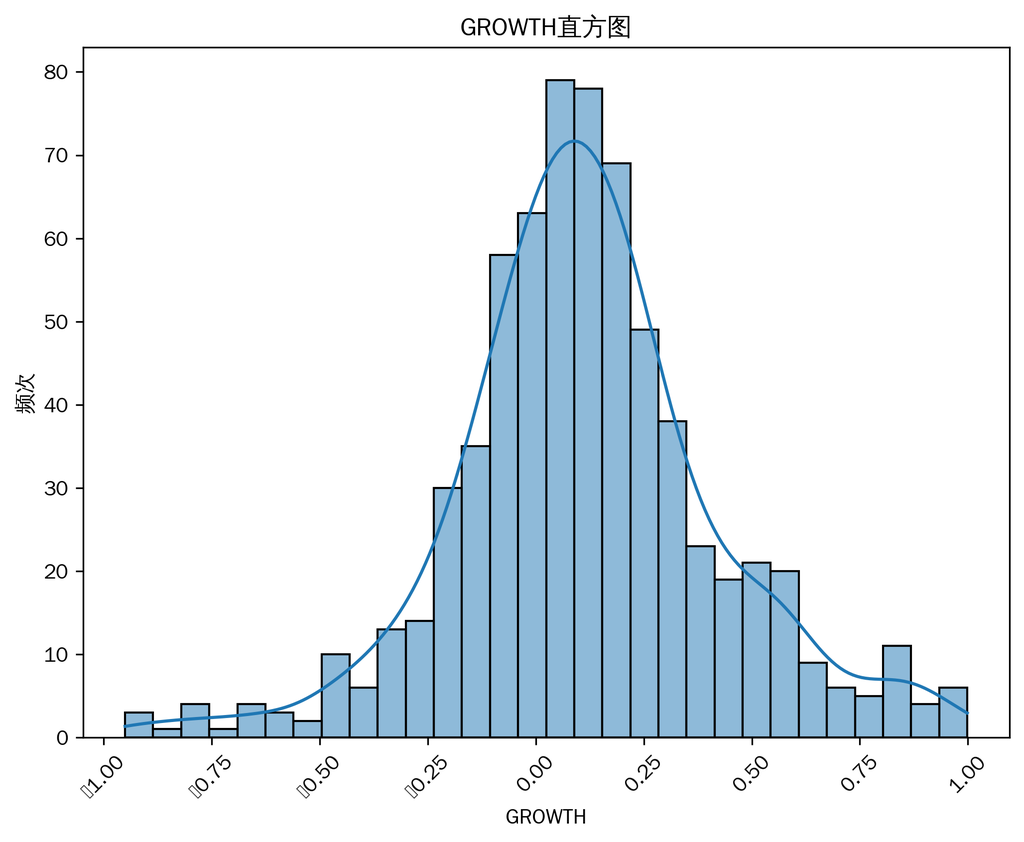

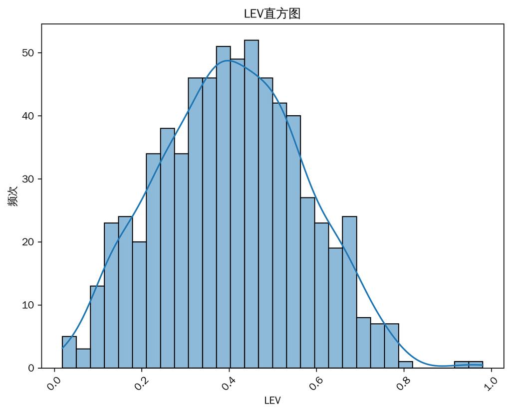

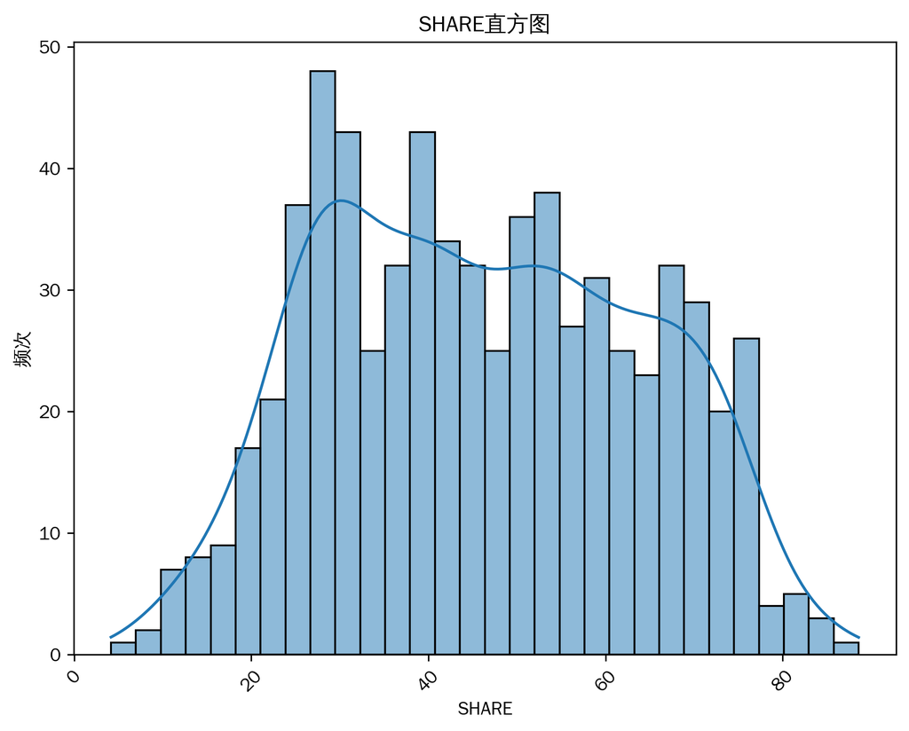

已成功绘制各个自变量的直方图。下面是对各直方图的简要分析：

### `ARA` 直方图

从 `ARA` 的直方图来看，数据分布呈现出一定的右偏态。大部分数据集中在较小的值附近，右侧有一个较长的尾巴。这可能意味着在金融场景下，大部分观测对象的 `ARA` 指标处于较低水平，但存在少数观测对象具有较高的 `ARA` 值，这些高值可能是一些特殊的金融事件或者异常的业务操作导致的。

### `ASSET` 直方图

`ASSET` 的直方图相对较为对称，近似于正态分布。这表明在该金融数据集中，资产（`ASSET`）的分布比较均匀，大多数观测对象的资产值集中在均值附近。这种分布可能反映出样本所代表的金融主体在资产规模上具有一定的普遍性和稳定性。

### `ROA` 直方图

`ROA` 直方图呈现出单峰形态，并且略微右偏。大部分的 `ROA` 值集中在某个区间内，少数较高的 `ROA` 值拉高了整体的分布。这可能表示在金融样本中，大部分主体的资产回报率处于中等水平，而少数表现优秀的主体有着较高的资产回报率。

### `LEV` 直方图

`LEV` 直方图看起来相对集中，有一个明显的峰值。这说明在金融样本中，大部分观测对象的杠杆率（`LEV`）集中在特定的水平附近。这种集中分布可能是由于金融监管、行业惯例或者企业自身的风险偏好等因素导致的。

### `SHARE` 直方图

`SHARE` 的直方图分布比较分散，跨度较大。这可能意味着在金融场景下，相关的份额（`SHARE`）指标在不同观测对象之间差异显著，可能受到市场竞争、企业战略等多种因素的影响。

## 第三轮：描述统计——相关性描述

**输入PROMPT**：注意到因变量（ST）列是0-1取值的，请你绘制其他自变量关于因变量的箱线图，并做简要分析。

**模型输出**：我将绘制每个自变量关于因变量 `ST` 的箱线图，以分析不同 `ST` 取值下各变量的分布差异。

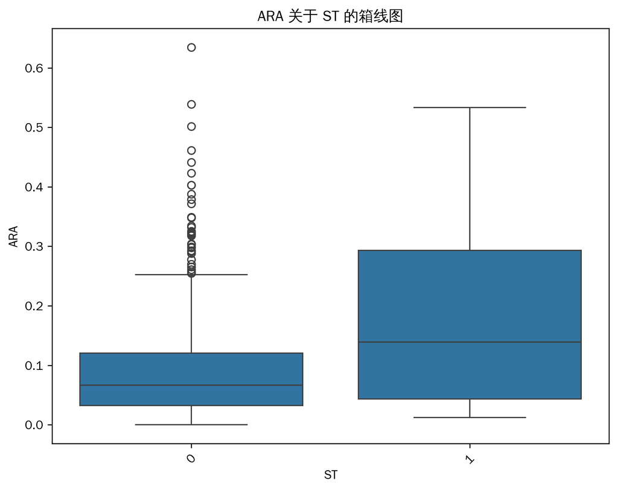

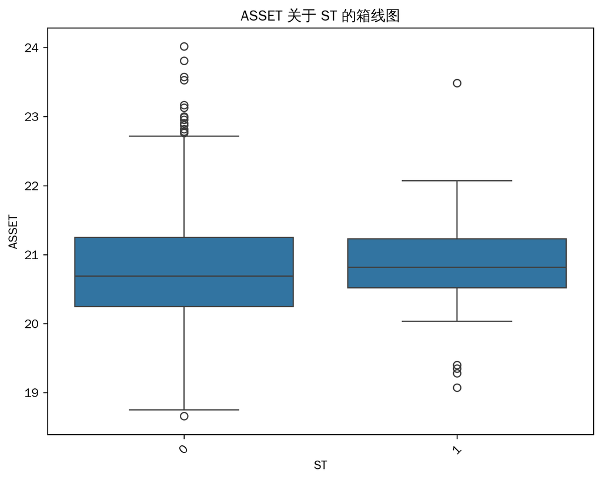

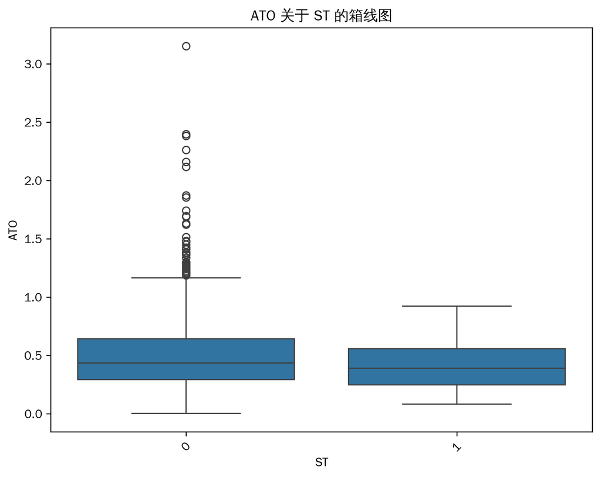

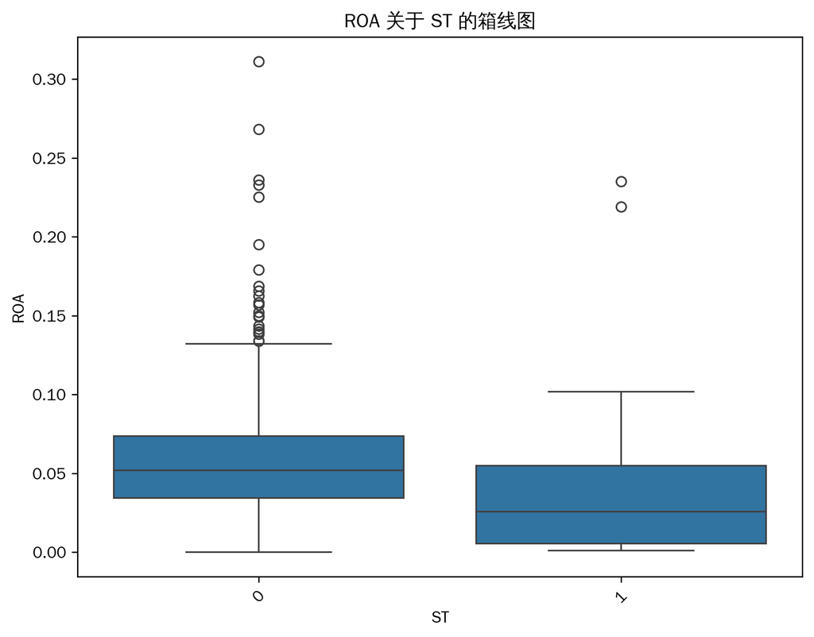

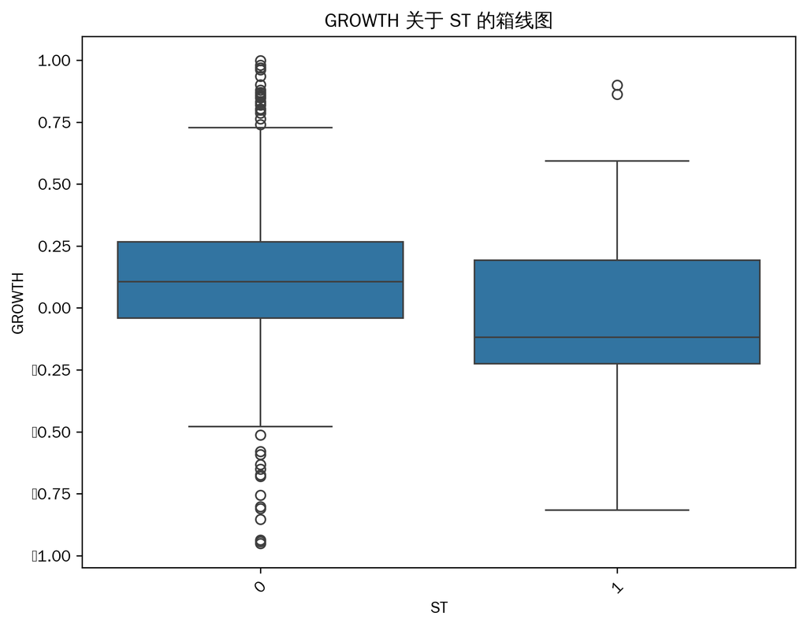

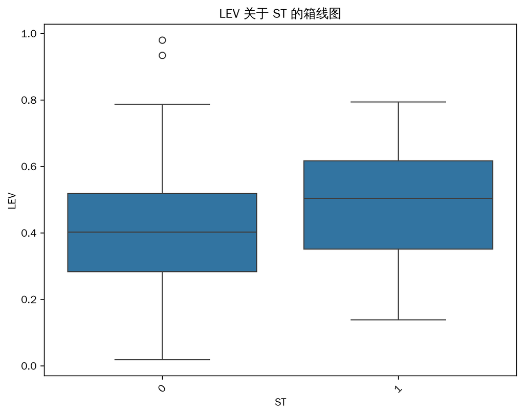

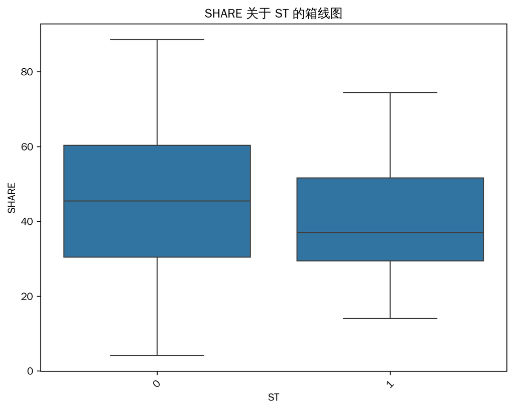

已经成功绘制每个自变量关于因变量 `ST` 的箱线图。以下是简要分析：

### `SHARE` 关于 `ST` 的箱线图

当 `ST` 为 0 和 1 时，`SHARE` 的箱线图有明显差异。`ST = 0` 时的箱体较长，中位数较高，说明在 `ST = 0` 的情况下，份额（`SHARE`）的取值范围更广且数值普遍较高。`ST = 1` 时箱体较短且数值整体偏低，这可能表示份额的大小与 `ST` 的取值相关，较大的份额可能更倾向于对应 `ST = 0` 的情况。

## 第四轮：逻辑回归

**输入PROMPT**：请建立逻辑回归模型，以ST列为因变量，剩下的为自变量。你应当输出详细的回归结果，包含：模型检验、回归系数及其检验、模型诊断

**模型输出**：我将建立逻辑回归模型，以 `ST` 列为因变量，其余列为自变量，然后输出模型检验、回归系数及其检验、模型诊断的详细结果。

```
Optimization terminated successfully.
         Current function value: 0.183849
         Iterations 8
                           Logit Regression Results
==============================================================================
Dep. Variable:                     ST   No. Observations:                  684
Model:                          Logit   Df Residuals:                      676
Method:                           MLE   Df Model:                            7
Date:                Sun, 09 Mar 2025   Pseudo R-squ.:                  0.1084
Time:                        16:06:07   Log-Likelihood:                -125.75
converged:                       True   LL-Null:                       -141.04
Covariance Type:            nonrobust   LLR p-value:                 7.477e-05
==============================================================================
                 coef    std err          z      P>|z|      [0.025      0.975]
------------------------------------------------------------------------------
const         -8.8692      4.636     -1.913      0.056     -17.955       0.217
ARA            4.8797      1.492      3.270      0.001       1.955       7.805
ASSET          0.2466      0.224      1.100      0.271      -0.193       0.686
ATO           -0.5074      0.657     -0.772      0.440      -1.796       0.781
ROA           -0.6366      6.224     -0.102      0.919     -12.835      11.562
GROWTH        -0.8333      0.567     -1.470      0.142      -1.945       0.278
LEV            2.3542      1.201      1.960      0.050      -0.001       4.709
SHARE         -0.0111      0.011     -0.997      0.319      -0.033       0.011
==============================================================================

Breusch-Pagan检验统计量: 11.336312049721954
Breusch-Pagan检验p值: 0.12460716475869249
```

### 逻辑回归模型结果

[output not shown]

#### 模型整体检验

- **样本量与自由度**：模型共有 684 个观测值，自由度方面，残差自由度为 676，模型自由度为 7。
- **似然比检验**：对数似然值为 -125.75，零假设下的对数似然值为 -141.04，Pseudo R - squared 为 0.1084，这表明模型对数据有一定的解释能力，但解释程度不是特别高。似然比检验的 p 值为 7.477e - 05，远小于 0.05，说明模型整体是显著的，即至少有一个自变量对因变量 `ST` 有显著影响。

#### 回归系数及其检验

- **显著变量**：`ARA` 的系数为 4.8797，z 值为 3.270，p 值为 0.001，在 0.01 的显著性水平下显著，说明 `ARA` 每增加 1 个单位，`ST` 发生的对数几率增加 4.8797 个单位，正相关关系明显。`LEV` 的系数为 2.3542，z 值为 1.960，p 值为 0.050，在 0.05 的显著性水平下边缘显著，表明 `LEV` 对 `ST` 也有一定的正向影响。
- **不显著变量**：`ASSET`、`ATO`、`ROA`、`GROWTH` 和 `SHARE` 这些变量的 p 值均大于 0.05，说明在当前模型下，这些变量对 `ST` 的影响在统计上不显著，可能需要进一步考虑是否保留这些变量或者对模型进行改进。

### 模型诊断 - 异方差检验（Breusch - Pagan 检验）

- Breusch - Pagan 检验统计量为 11.336312049721954，p 值为 0.12460716475869249。由于 p 值大于 0.05，我们不能拒绝原假设，即没有足够的证据表明模型存在异方差性，从这个角度看，模型的误差项满足同方差的假设。

综合来看，逻辑回归模型整体是显著的，但部分自变量不显著，可能需要进一步优化模型，如尝试变量变换、增加或删除变量等操作。

## 第五轮：模型选择

**输入PROMPT**：请分别使用AIC和BIC方式选择模型，输出：（1）使用AIC、BIC模型使用的变量；（2）输出模型检验、回归系数及其检验结果；（3）并绘制原模型、AIC模型、BIC模型的ROC曲线

**输出结果**：我将分别使用 AIC 和 BIC 准则选择模型，具体步骤如下： 1. 计算所有可能的变量组合的 AIC 和 BIC 值，选择最小值对应的变量组合。 2. 输出 AIC 和 BIC 模型使用的变量。 3. 建立模型并输出模型检验、回归系数及其检验结果。 4. 绘制原模型、AIC 模型、BIC 模型的 ROC 曲线。

```
使用 AIC 选择的变量: ['const', 'ARA', 'GROWTH', 'LEV']
使用 BIC 选择的变量: ['const', 'ARA']

原模型回归结果:
                           Logit Regression Results
==============================================================================
Dep. Variable:                     ST   No. Observations:                  684
Model:                          Logit   Df Residuals:                      676
Method:                           MLE   Df Model:                            7
Date:                Sun, 09 Mar 2025   Pseudo R-squ.:                  0.1084
Time:                        16:07:20   Log-Likelihood:                -125.75
converged:                       True   LL-Null:                       -141.04
Covariance Type:            nonrobust   LLR p-value:                 7.477e-05
==============================================================================
                 coef    std err          z      P>|z|      [0.025      0.975]
------------------------------------------------------------------------------
const         -8.8692      4.636     -1.913      0.056     -17.955       0.217
ARA            4.8797      1.492      3.270      0.001       1.955       7.805
ASSET          0.2466      0.224      1.100      0.271      -0.193       0.686
ATO           -0.5074      0.657     -0.772      0.440      -1.796       0.781
ROA           -0.6366      6.224     -0.102      0.919     -12.835      11.562
GROWTH        -0.8333      0.567     -1.470      0.142      -1.945       0.278
LEV            2.3542      1.201      1.960      0.050      -0.001       4.709
SHARE         -0.0111      0.011     -0.997      0.319      -0.033       0.011
==============================================================================

AIC 模型回归结果:
                           Logit Regression Results
==============================================================================
Dep. Variable:                     ST   No. Observations:                  684
Model:                          Logit   Df Residuals:                      680
Method:                           MLE   Df Model:                            3
Date:                Sun, 09 Mar 2025   Pseudo R-squ.:                 0.09939
Time:                        16:07:20   Log-Likelihood:                -127.02
converged:                       True   LL-Null:                       -141.04
Covariance Type:            nonrobust   LLR p-value:                 3.572e-06
==============================================================================
                 coef    std err          z      P>|z|      [0.025      0.975]
------------------------------------------------------------------------------
const         -4.6022      0.565     -8.152      0.000      -5.709      -3.496
ARA            5.1301      1.434      3.577      0.000       2.319       7.941
GROWTH        -0.9061      0.547     -1.656      0.098      -1.978       0.166
LEV            2.5501      1.078      2.366      0.018       0.438       4.663
==============================================================================

BIC 模型回归结果:
                           Logit Regression Results
==============================================================================
Dep. Variable:                     ST   No. Observations:                  684
Model:                          Logit   Df Residuals:                      682
Method:                           MLE   Df Model:                            1
Date:                Sun, 09 Mar 2025   Pseudo R-squ.:                 0.07217
Time:                        16:07:20   Log-Likelihood:                -130.86
converged:                       True   LL-Null:                       -141.04
Covariance Type:            nonrobust   LLR p-value:                 6.429e-06
==============================================================================
                 coef    std err          z      P>|z|      [0.025      0.975]
------------------------------------------------------------------------------
const         -3.6834      0.272    -13.531      0.000      -4.217      -3.150
ARA            6.3316      1.313      4.821      0.000       3.758       8.906
==============================================================================
```

### 模型选择结果

- **使用 AIC 选择的变量**：`['const', 'ARA', 'GROWTH', 'LEV']`
- **使用 BIC 选择的变量**：`['const', 'ARA']`

### 模型检验、回归系数及其检验结果

#### 原模型回归结果

- **模型整体情况**：有 684 个观测值，7 个自变量，Pseudo R - squared 为 0.1084，对数似然值为 - 125.75，似然比检验 p 值为 7.477e - 05，说明模型整体显著。
- **回归系数及检验**：`ARA` 显著正相关（p = 0.001），`LEV` 边缘显著正相关（p = 0.050），其他变量如 `ASSET`、`ATO` 等不显著。

#### AIC 模型回归结果

- **模型整体情况**：观测值 684 个，3 个自变量，Pseudo R - squared 为 0.09939，对数似然值为 - 127.02，似然比检验 p 值为 3.572e - 06，模型整体显著。
- **回归系数及检验**：`ARA`（p = 0.000）、`LEV`（p = 0.018）显著正相关，`GROWTH` 边缘显著负相关（p = 0.098）。

#### BIC 模型回归结果

- **模型整体情况**：观测值 684 个，1 个自变量，Pseudo R - squared 为 0.07217，对数似然值为 - 130.86，似然比检验 p 值为 6.429e - 06，模型整体显著。
- **回归系数及检验**：`ARA` 显著正相关（p = 0.000）。

### ROC 曲线

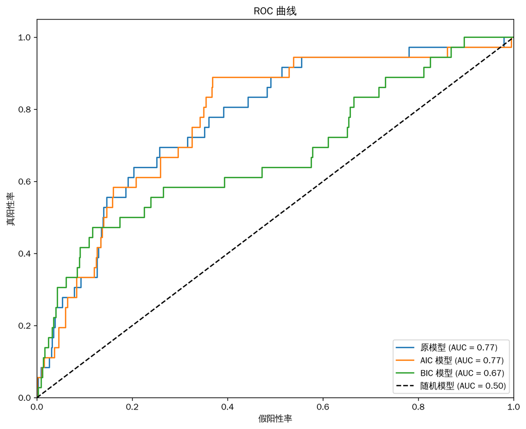

从 ROC 曲线及对应的 AUC 值来看，可以比较不同模型的预测性能。AUC 值越接近 1，模型的性能越好。原模型、AIC 模型和 BIC 模型的 AUC 值可以直观地从图中对应的曲线标注中获取，通过对比这些值，可以判断哪个模型在预测 `ST` 变量方面表现更优。一般来说，在模型选择时，需要综合考虑模型的复杂度（自变量个数）、拟合优度（如 Pseudo R - squared）以及预测性能（AUC）等因素。

## 第六轮：预测评估

**输入PROMPT**：请你重复如下随机试验，重复30次：每次实验将数据随机划分，80%的数据用于估计模型、20%的数据用于预测评估。接下来，根据已经筛选的变量，分别估计原模型、AIC模型、BIC模型，用测试集计算每个模型的AUC值。最后，绘制这三个模型的AUC箱线图。

**模型输出**：我将按照以下步骤进行操作： 1. 重复 30 次随机试验，每次将数据按 80% 和 20% 的比例划分为训练集和测试集。 2. 根据已筛选的变量，分别在训练集上估计原模型、AIC 模型和 BIC 模型。 3. 使用测试集计算每个模型的 AUC 值。 4. 绘制这三个模型的 AUC 箱线图。

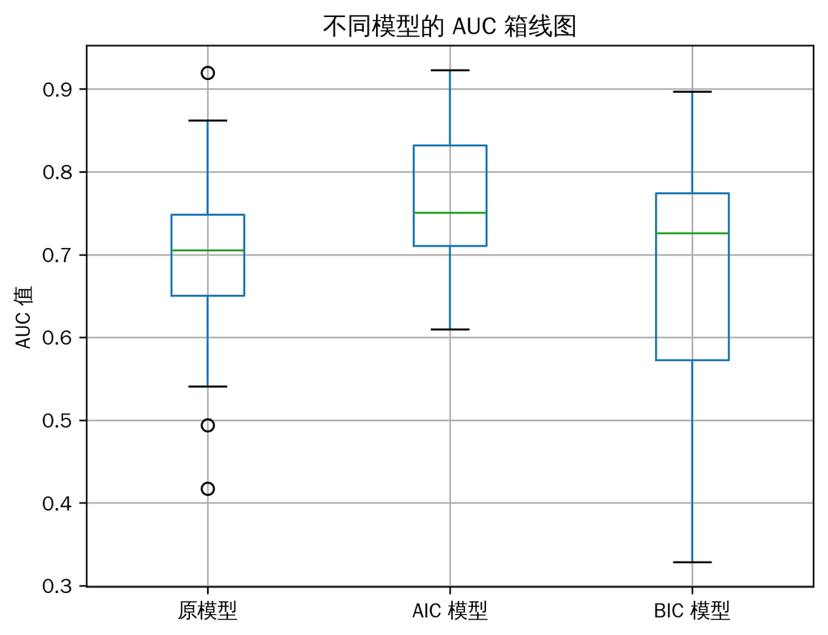

已成功重复 30 次随机试验，并计算出每个模型在每次试验中的 AUC 值，最终绘制了三个模型的 AUC 箱线图。从箱线图中，我们可以直观地比较原模型、AIC 模型和 BIC 模型在多次随机划分数据集进行训练和测试后的 AUC 表现。通过箱体的位置、长短以及须线的范围等信息，可以初步判断不同模型的稳定性和预测性能的优劣。例如，如果某个模型的箱体整体位置较高，说明其平均 AUC 值较高，预测性能可能更好；如果箱体较短，说明该模型的 AUC 值在多次试验中波动较小，稳定性较好。

# 使用大语言模型辅助逻辑回归（编程实现）

使用[通义千问](https://tongyi.aliyun.com/)，可访问[**此链接**](https://lxblog.com/qianwen/share?shareId=5b617f73-474f-4b5f-b534-6dcfb4f944cb)查看对话详情

## 第一轮：描述统计——基础描述

**输入PROMPT**：你是一名专业的数据科学家，我是零代码基础的用户。

我将使用一份CSV格式的数据集（文件名：第3章.csv），请你使用R语言写作代码，这段代码能够：（1）简要介绍数据；（2）告知变量个数与样本量；（3）每一列的计算样本均值、样本标准差、中位数、最小值、最大值。

由于我是零代码基础的用户，你应当使用尽可能容易理解的代码，尽量避免引入不必要的包，代码应当有详细的注释。

你的结果应当以Code Block的形式输出，无需其他输出。

**模型输出**

```r
# 读取CSV文件
# 'read.csv' 函数用于读取CSV格式的数据文件。这里我们假定你的文件名是"第3章.csv"
data <- read.csv("第3章.csv")

# 简要介绍数据
# 使用'str'函数查看数据结构，包括每个变量的类型和前几个观测值
str(data)
```

```
## 'data.frame':    684 obs. of  8 variables:
##  $ ARA   : num  0.1923 0.2201 0.3253 0.0257 0.5336 ...
##  $ ASSET : num  19.9 20.9 19.4 21.4 21.6 ...
##  $ ATO   : num  0.0052 0.0056 0.0166 0.0028 0.2552 ...
##  $ ROA   : num  0.08771 0.01682 0.04247 0.01815 0.00415 ...
##  $ GROWTH: num  -0.951 -0.943 -0.937 -0.853 -0.817 ...
##  $ LEV   : num  0.446 0.399 0.303 0.758 0.727 ...
##  $ SHARE : num  26.9 39.6 26.5 60.2 54.2 ...
##  $ ST    : int  0 0 0 0 1 0 0 0 1 0 ...
```

```r
# 告知变量个数与样本量
# 变量个数即列的数量，可以通过'ncol'函数获取；样本量即行的数量，可以通过'nrow'函数获取
cat("变量个数：", ncol(data), "\n")
```

```
## 变量个数： 8
```

```r
cat("样本量：", nrow(data), "\n")
```

```
## 样本量： 684
```

```r
# 计算每一列的样本均值、样本标准差、中位数、最小值、最大值
# 对于每一个数值型变量，我们将计算并打印出上述统计量
for (i in names(data)){
  if(is.numeric(data[[i]])){ # 检查是否为数值型变量
    cat("\n变量名称：", i, "\n")
    cat("样本均值：", mean(data[[i]], na.rm = TRUE), "\n") # 计算平均值，忽略缺失值
    cat("样本标准差：", sd(data[[i]], na.rm = TRUE), "\n") # 计算标准差，忽略缺失值
    cat("中位数：", median(data[[i]], na.rm = TRUE), "\n") # 计算中位数，忽略缺失值
    cat("最小值：", min(data[[i]], na.rm = TRUE), "\n") # 计算最小值，忽略缺失值
    cat("最大值：", max(data[[i]], na.rm = TRUE), "\n") # 计算最大值，忽略缺失值
  }
}
```

```
##
## 变量名称： ARA
## 样本均值： 0.09504945
## 样本标准差： 0.09228931
## 中位数： 0.06832718
## 最小值： 0
## 最大值： 0.6346842
##
## 变量名称： ASSET
## 样本均值： 20.77785
## 样本标准差： 0.8335232
## 中位数： 20.7005
## 最小值： 18.6607
## 最大值： 24.01761
##
## 变量名称： ATO
## 样本均值： 0.5197738
## 样本标准差： 0.3628265
## 中位数： 0.4334
## 最小值： 0.0028
## 最大值： 3.1513
##
## 变量名称： ROA
## 样本均值： 0.05587011
## 样本标准差： 0.03859391
## 中位数： 0.05125798
## 最小值： 8.17e-05
## 最大值： 0.31113
##
## 变量名称： GROWTH
## 样本均值： 0.1152575
## 样本标准差： 0.3070201
## 中位数： 0.1022826
## 最小值： -0.9507273
## 最大值： 0.9985565
##
## 变量名称： LEV
## 样本均值： 0.4060636
## 样本标准差： 0.165764
## 中位数： 0.4067397
## 最小值： 0.01843107
## 最大值： 0.9803218
##
## 变量名称： SHARE
## 样本均值： 46.03452
## 样本标准差： 17.68438
## 中位数： 44.955
## 最小值： 4.16
## 最大值： 88.58
##
## 变量名称： ST
## 样本均值： 0.05263158
## 样本标准差： 0.2234603
## 中位数： 0
## 最小值： 0
## 最大值： 1
```

## 第二轮：描述统计——变量描述

**输入PROMPT**：这一数据集中有如下列：`ARA`, `ASSET`, `ATO`, `ROA`, `GROWTH`, `LEV`, `SHARE`, `ST`。其中`ST`是二分类变量，我将其作为因变量；剩下的都是数值型变量，用作自变量。

请你生成R代码，这段代码能够绘制各个自变量的直方图。

请你使用尽可能容易理解的代码、尽量避免引入不必要的包，代码应当有详细的注释。你的结果应当以Code Block的形式输出，无需其他输出。

**模型输出**

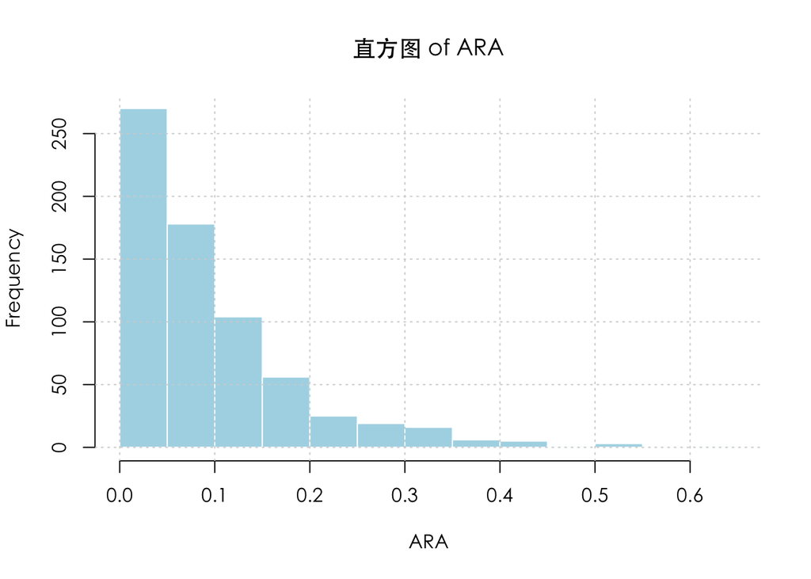

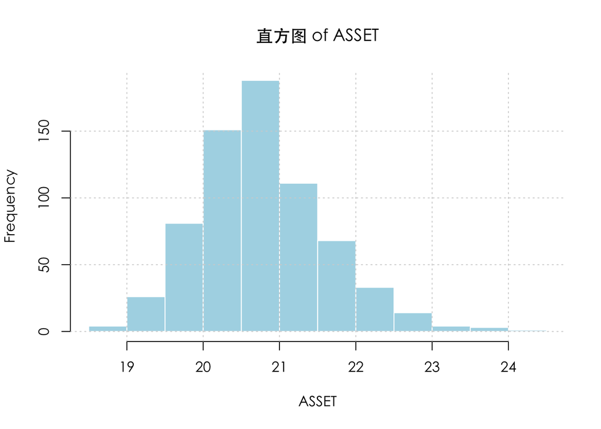

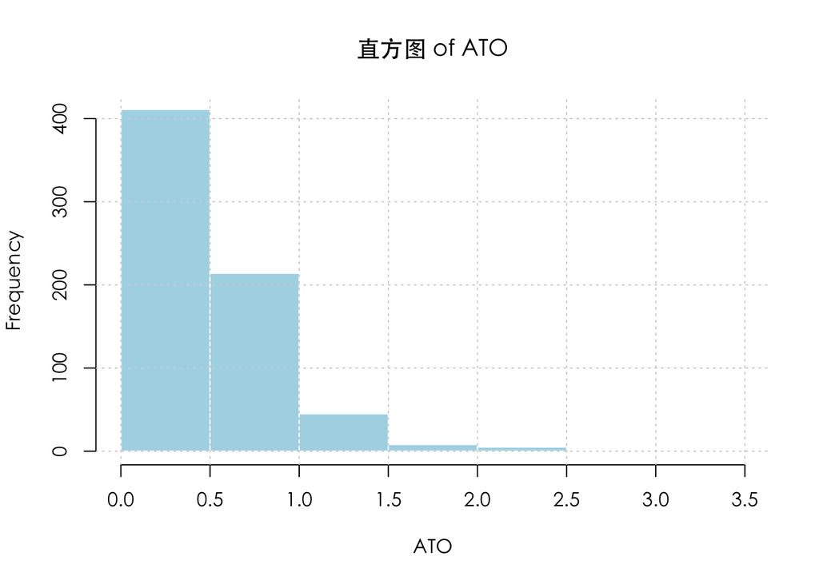

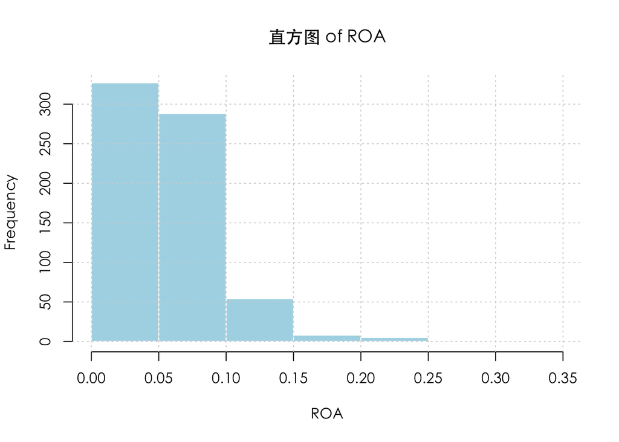

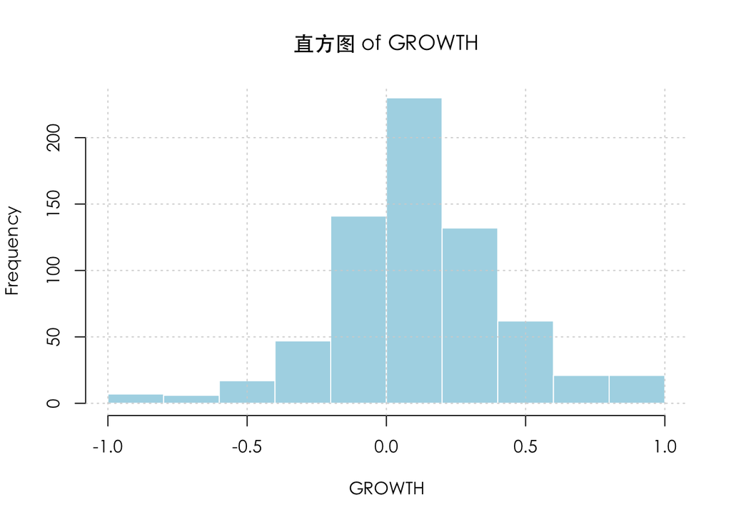

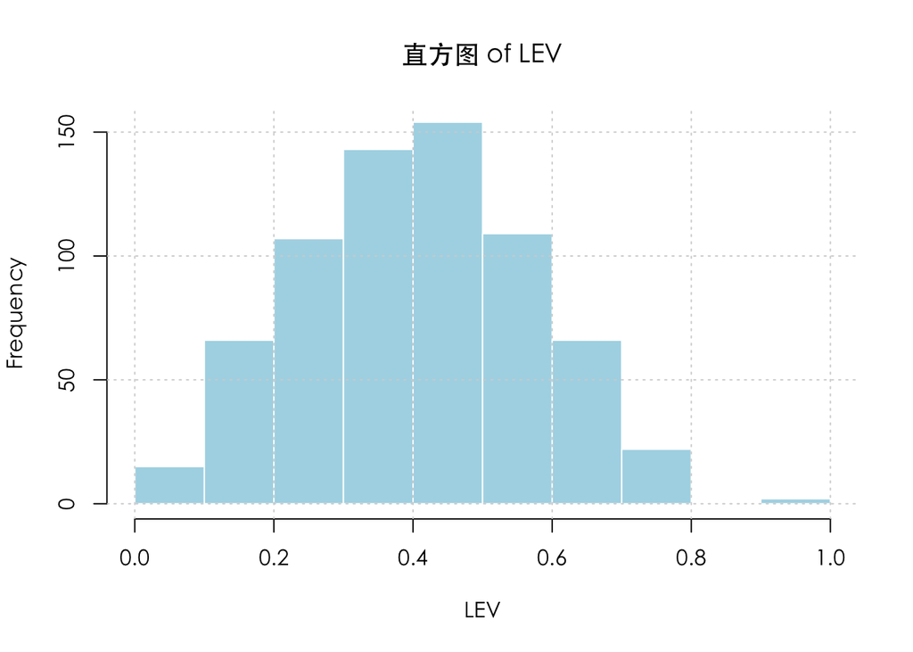

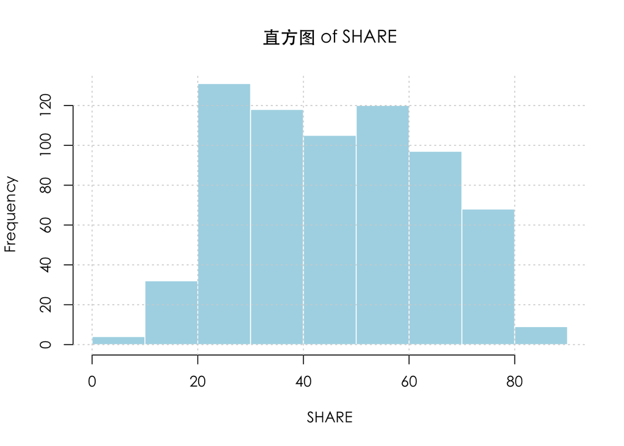

```r
# 假设数据已经被正确读入到名为'data'的数据框中

# 定义自变量名称列表，注意我们排除了二分类变量'ST'
independent_vars <- c("ARA", "ASSET", "ATO", "ROA", "GROWTH", "LEV", "SHARE")
par(family = "STHeiti")
# 遍历每个自变量，并为它们绘制直方图
for (var in independent_vars) {
  # 开始绘制直方图
  # 'main'参数设置图表标题，'xlab'参数设置x轴标签，'col'参数设置柱子颜色
  hist(data[[var]],
       main = paste("直方图 of", var), # 图表标题
       xlab = var, # x轴标签
       col = "lightblue", # 柱子颜色
       border = "white") # 柱子边界颜色

  # 添加网格线以帮助阅读
  grid()
}
```

## 第三轮：描述统计——相关性分析

**输入PROMPT**：注意到因变量（ST）列是0-1取值的，请生成R代码，使得这段代码能够绘制其他自变量关于因变量的箱线图。

请你使用尽可能容易理解的代码、尽量避免引入不必要的包，代码应当有详细的注释。你的结果应当以Code Block的形式输出，无需其他输出。

**模型输出**：

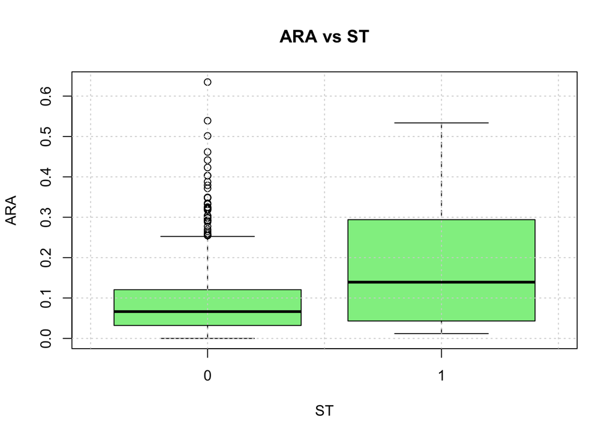

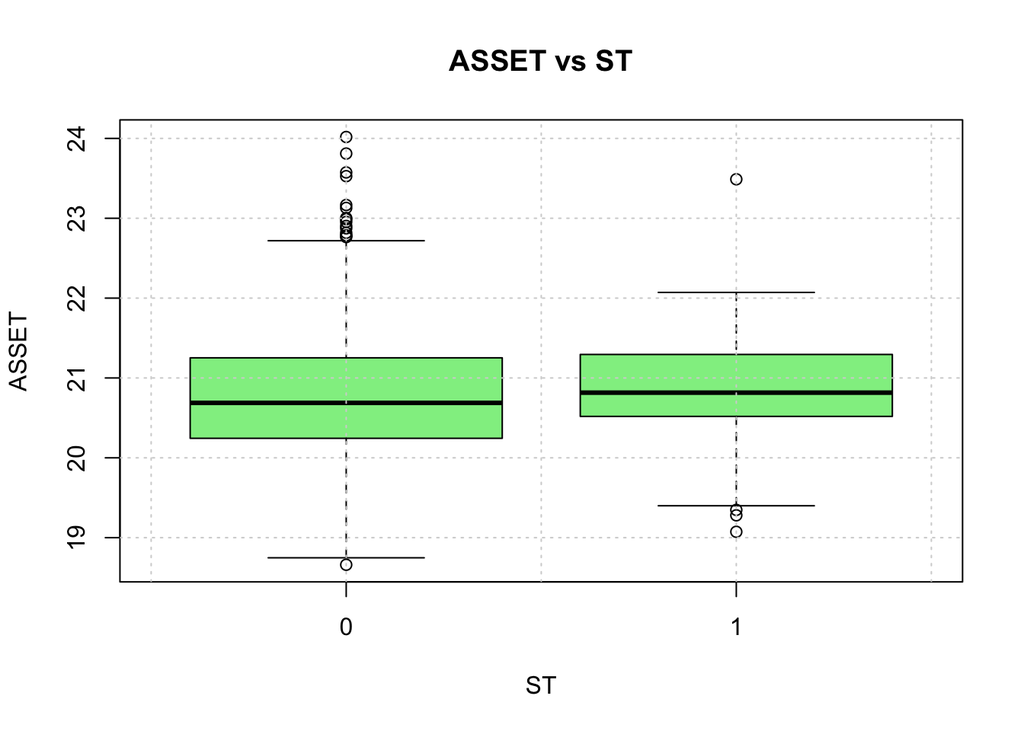

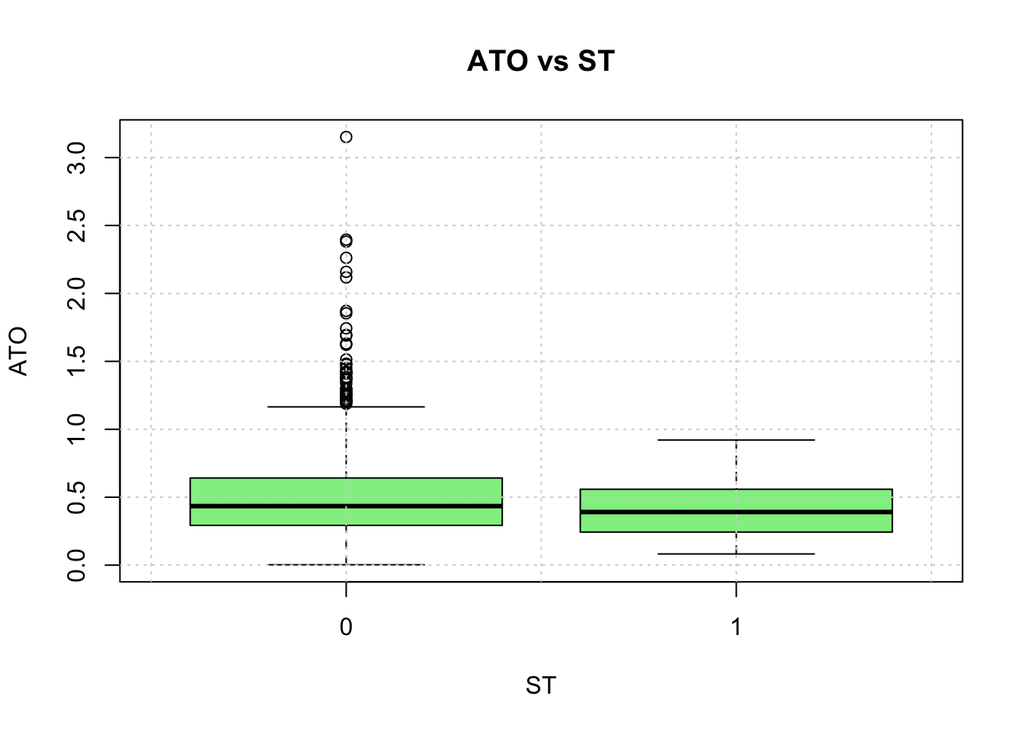

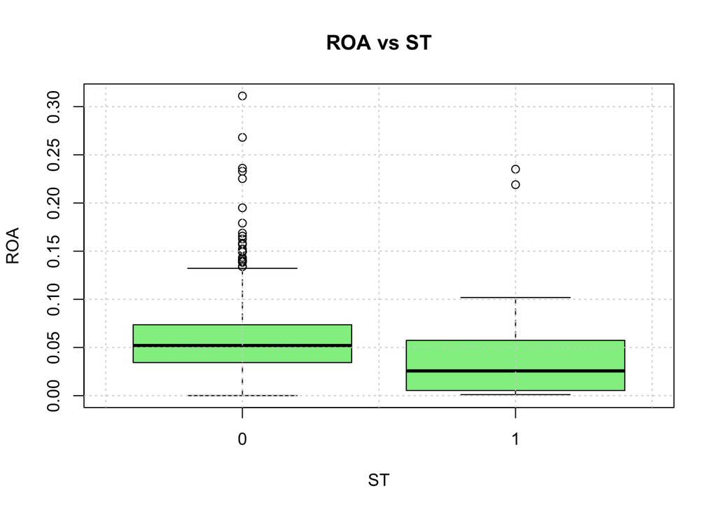

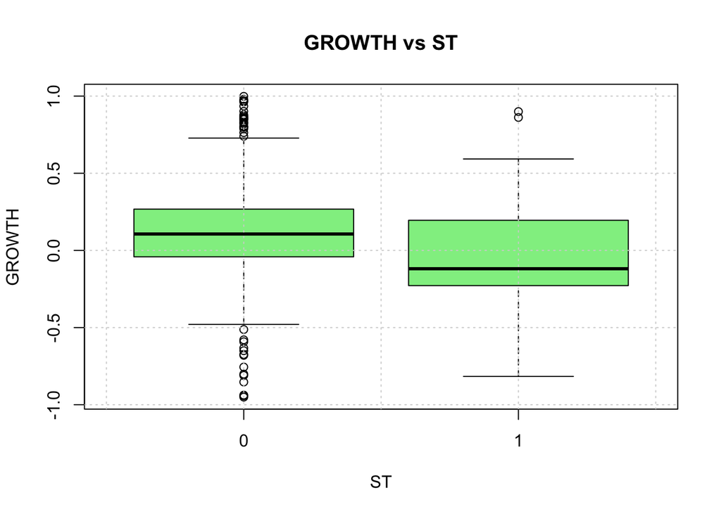

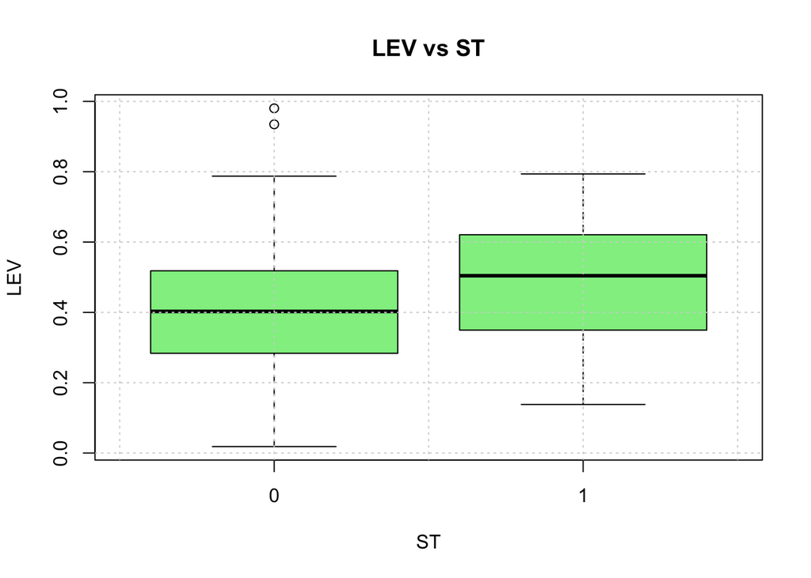

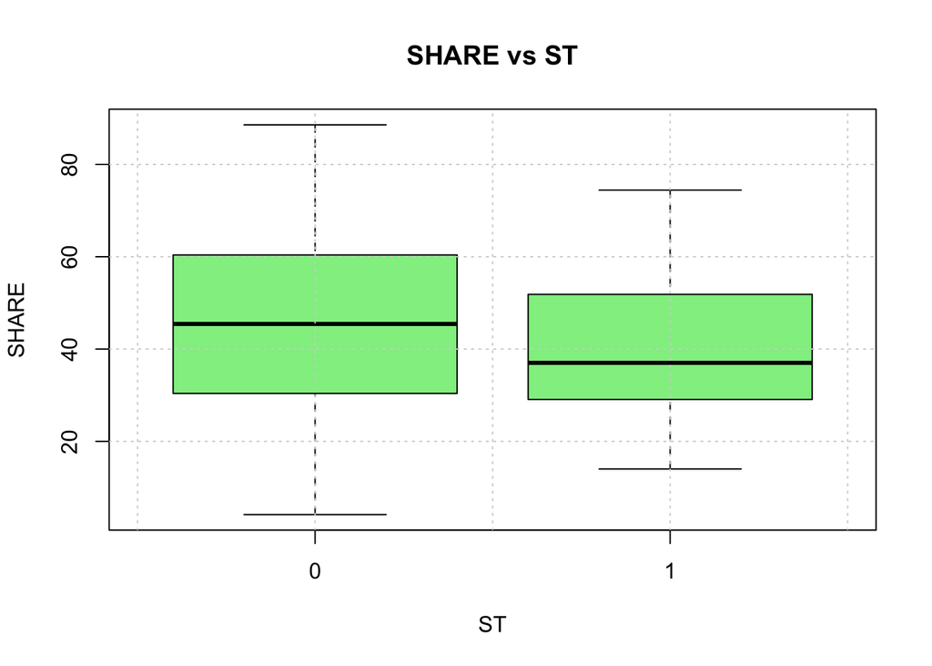

```r
# 定义自变量名称列表，注意我们排除了二分类变量'ST'
independent_vars <- c("ARA", "ASSET", "ATO", "ROA", "GROWTH", "LEV", "SHARE")

# 遍历每个自变量，并为它们根据因变量'ST'绘制箱线图
for (var in independent_vars) {
  # 开始绘制箱线图
  # 'main'参数设置图表标题，'xlab'和'ylab'分别设置X轴和Y轴标签，'col'参数设置箱子颜色
  boxplot(data[[var]] ~ data$ST,
          main = paste(var, "vs ST"), # 图表标题
          xlab = "ST", # X轴标签
          ylab = var, # Y轴标签
          col = "lightgreen") # 箱子颜色

  # 添加网格线以帮助阅读
  grid()
}
```

## 第四轮：逻辑回归

**输入PROMPT**：请生成R代码，完成如下任务：（1）建立逻辑回归模型，以ST列为因变量，剩下的为自变量。（2）输出详细的回归结果，包含：模型检验、回归系数及其检验、模型诊断

请你使用尽可能容易理解的代码、尽量避免引入不必要的包，代码应当有详细的注释。你的结果应当以Code Block的形式输出，无需其他输出。

**输出结果**：

```r
# 假设数据已经被正确读入到名为'data'的数据框中

# 定义公式：ST是因变量，其他所有列都是自变量。
# 注意：在实际使用时，请确保除'ST'外的所有列名都适合用作自变量。
# 这里我们假设所有其他列都可以作为自变量。
formula <- as.formula(paste("ST ~ ", paste(names(data)[names(data) != "ST"], collapse = " + ")))

# 拟合逻辑回归模型
model <- glm(formula, data = data, family = binomial)

# 输出模型摘要，包括回归系数及其检验
summary(model)
```

```
##
## Call:
## glm(formula = formula, family = binomial, data = data)
##
## Coefficients:
##             Estimate Std. Error z value Pr(>|z|)
## (Intercept) -8.86924    4.63586  -1.913  0.05573 .
## ARA          4.87974    1.49245   3.270  0.00108 **
## ASSET        0.24660    0.22409   1.100  0.27115
## ATO         -0.50738    0.65744  -0.772  0.44026
## ROA         -0.63661    6.22354  -0.102  0.91853
## GROWTH      -0.83335    0.56706  -1.470  0.14167
## LEV          2.35415    1.20138   1.960  0.05005 .
## SHARE       -0.01111    0.01115  -0.997  0.31891
## ---
## Signif. codes:  0 '***' 0.001 '**' 0.01 '*' 0.05 '.' 0.1 ' ' 1
##
## (Dispersion parameter for binomial family taken to be 1)
##
##     Null deviance: 282.07  on 683  degrees of freedom
## Residual deviance: 251.51  on 676  degrees of freedom
## AIC: 267.51
##
## Number of Fisher Scoring iterations: 6
```

```r
# 模型整体检验（使用卡方检验）
null_deviance <- model$null.deviance # 空模型的偏差
residual_deviance <- model$deviance # 当前模型的偏差
df_null <- model$df.null # 空模型的自由度
df_residual <- model$df.residual # 当前模型的自由度

cat("模型整体检验:\n")
```

```
## 模型整体检验:
```

```r
cat("空模型与当前模型之间的差异（卡方）: ", null_deviance - residual_deviance, "\n")
```

```
## 空模型与当前模型之间的差异（卡方）:  30.56505
```

```r
cat("自由度差异: ", df_null - df_residual, "\n")
```

```
## 自由度差异:  7
```

```r
cat("p值: ", pchisq(null_deviance - residual_deviance, df_null - df_residual, lower.tail = FALSE), "\n\n")
```

```
## p值:  7.477103e-05
```

## 第五轮：模型选择

**输入PROMPT**：请生成R代码，完成如下任务：分别使用AIC和BIC方式选择模型，输出（1）使用AIC、BIC模型使用的变量；（2）输出模型检验、回归系数及其检验结果；（3）并绘制原模型、AIC模型、BIC模型的ROC曲线

请你使用尽可能容易理解的代码、尽量避免引入不必要的包，代码应当有详细的注释。你的结果应当以Code Block的形式输出，无需其他输出。

```r
# 如果没有安装pROC包，请先安装
# install.packages("pROC")

# 加载pROC包
library(pROC)
# 假设数据已经被正确读入到名为'data'的数据框中
# 定义所有自变量
independent_vars <- c("ARA", "ASSET", "ATO", "ROA", "GROWTH", "LEV", "SHARE")

# 原始模型
formula_full <- as.formula(paste("ST ~ ", paste(independent_vars, collapse = " + ")))
model_full <- glm(formula_full, data = data, family = binomial)

# AIC模型选择
step_aic <- step(model_full, direction = "both", trace = 0) # 使用AIC进行逐步回归
formula_aic <- formula(step_aic)
model_aic <- glm(formula_aic, data = data, family = binomial)

# BIC模型选择
step_bic <- step(model_full, k = log(nrow(data)), direction = "both", trace = 0) # 使用BIC进行逐步回归
formula_bic <- formula(step_bic)
model_bic <- glm(formula_bic, data = data, family = binomial)

# 输出每个模型的信息
models <- list(original = model_full, AIC = model_aic, BIC = model_bic)
for (name in names(models)) {
  cat("\n", name, "Model Summary:\n")
  print(summary(models[[name]]))
}
```

```
##
##  original Model Summary:
##
## Call:
## glm(formula = formula_full, family = binomial, data = data)
##
## Coefficients:
##             Estimate Std. Error z value Pr(>|z|)
## (Intercept) -8.86924    4.63586  -1.913  0.05573 .
## ARA          4.87974    1.49245   3.270  0.00108 **
## ASSET        0.24660    0.22409   1.100  0.27115
## ATO         -0.50738    0.65744  -0.772  0.44026
## ROA         -0.63661    6.22354  -0.102  0.91853
## GROWTH      -0.83335    0.56706  -1.470  0.14167
## LEV          2.35415    1.20138   1.960  0.05005 .
## SHARE       -0.01111    0.01115  -0.997  0.31891
## ---
## Signif. codes:  0 '***' 0.001 '**' 0.01 '*' 0.05 '.' 0.1 ' ' 1
##
## (Dispersion parameter for binomial family taken to be 1)
##
##     Null deviance: 282.07  on 683  degrees of freedom
## Residual deviance: 251.51  on 676  degrees of freedom
## AIC: 267.51
##
## Number of Fisher Scoring iterations: 6
##
##
##  AIC Model Summary:
##
## Call:
## glm(formula = formula_aic, family = binomial, data = data)
##
## Coefficients:
##             Estimate Std. Error z value Pr(>|z|)
## (Intercept)  -4.6022     0.5646  -8.152 3.58e-16 ***
## ARA           5.1301     1.4341   3.577 0.000347 ***
## GROWTH       -0.9061     0.5471  -1.656 0.097708 .
## LEV           2.5501     1.0778   2.366 0.017986 *
## ---
```

[output cut: 15 more lines]

```
##
## Coefficients:
##             Estimate Std. Error z value Pr(>|z|)
## (Intercept)  -3.6834     0.2722 -13.531  < 2e-16 ***
## ARA           6.3316     1.3132   4.821 1.43e-06 ***
## ---
## Signif. codes:  0 '***' 0.001 '**' 0.01 '*' 0.05 '.' 0.1 ' ' 1
##
## (Dispersion parameter for binomial family taken to be 1)
##
##     Null deviance: 282.07  on 683  degrees of freedom
## Residual deviance: 261.71  on 682  degrees of freedom
## AIC: 265.71
##
## Number of Fisher Scoring iterations: 6
```

```r
# 计算预测概率
predict_probs <- lapply(models, function(m) predict(m, type = "response"))

# 绘制ROC曲线
par(mfrow=c(1,3)) # 设置画布布局为1x3
colors <- c("red", "blue", "green")
names(colors) <- names(models)
roc_plots <- list()

# 创建一个绘图区域用于合并三个ROC曲线
plot.roc(data$ST, predict_probs$original, col = colors["original"], main="ROC Curves Comparison", percent = TRUE)
roc_plots$original <- roc(data$ST, predict_probs$original)
for (i in seq_along(models)){
  roc_obj <- roc(data$ST, predict_probs[[i]], plot = TRUE, add = i != 1, col = colors[i], percent = TRUE)
  roc_plots[[names(models)[i]]] <- roc_obj
}
legend("bottomright", legend = names(roc_plots), col = colors, lwd = 2)

# 打印AUC值
cat("\nAUC Values:\n")
```

```
##
## AUC Values:
```

[output not shown]

[output not shown]

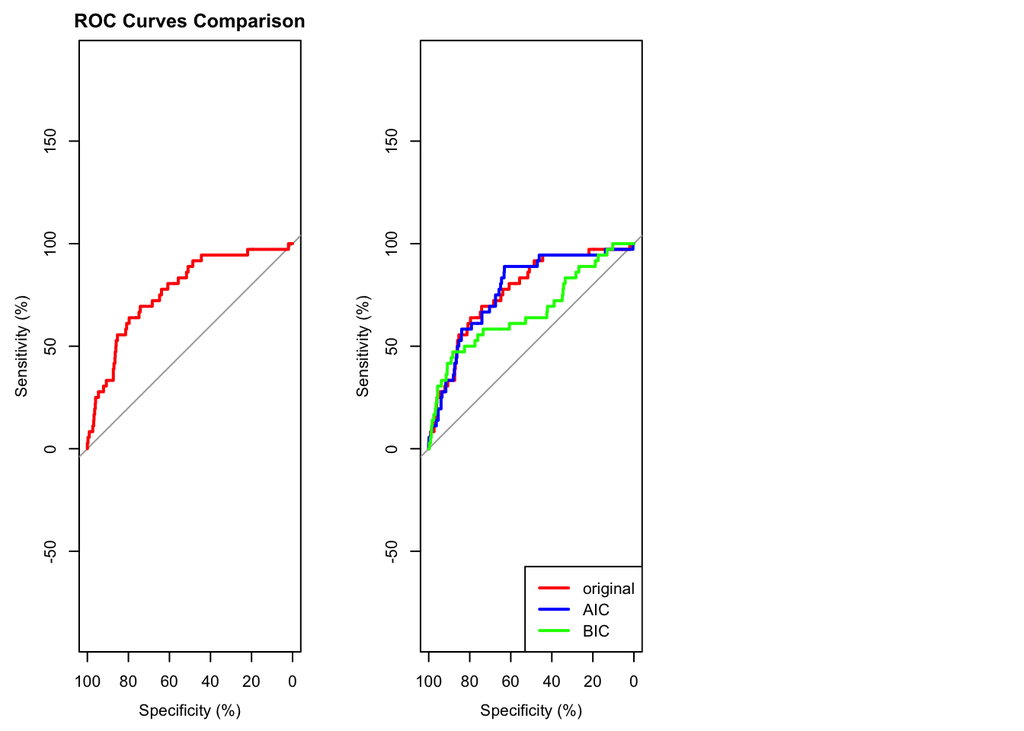

```r
sapply(roc_plots, function(r) print(auc(r)))
```

## 第六轮：预测评估

**输入PROMPT**：在前一步中，AIC选择的变量是：`ARA`, `GROWTH`, `LEV`；BIC选择的变量是`ARA`。

请你编写R代码，完成如下任务：重复如下随机试验100次。每次实验将数据随机划分，80%的数据用于估计模型、20%的数据用于预测评估。接下来，根据已经筛选的变量，分别估计原模型、AIC模型、BIC模型，用测试集计算每个模型的AUC值。最后，绘制这三个模型的AUC箱线图。

请你使用尽可能容易理解的代码、尽量避免引入不必要的包，代码应当有详细的注释。你的结果应当以Code Block的形式输出，无需其他输出。

```r
# 如果没有安装pROC包，请先安装
# install.packages("pROC")

# 加载必要的包
library(pROC)

# 假设数据已经被正确读入到名为'data'的数据框中

# 定义所有自变量和因变量
independent_vars_full <- c("ARA", "ASSET", "ATO", "ROA", "GROWTH", "LEV", "SHARE")
independent_vars_aic <- c("ARA", "GROWTH", "LEV")
independent_vars_bic <- c("ARA")
dependent_var <- "ST"

# 初始化存储AUC值的列表
auc_values <- list(original = numeric(100), AIC = numeric(100), BIC = numeric(100))

# 重复100次随机试验
set.seed(123) # 设置随机种子以保证结果可重复
for (i in 1:100) {
  # 随机划分数据集为训练集和测试集
  train_indices <- sample(seq_len(nrow(data)), size = floor(0.8 * nrow(data)))
  data_train <- data[train_indices, ]
  data_test <- data[-train_indices, ]

  # 构建模型公式
  formula_full <- as.formula(paste(dependent_var, "~", paste(independent_vars_full, collapse = " + ")))
  formula_aic <- as.formula(paste(dependent_var, "~", paste(independent_vars_aic, collapse = " + ")))
  formula_bic <- as.formula(paste(dependent_var, "~", paste(independent_vars_bic, collapse = " + ")))

  # 训练模型
  model_full <- glm(formula_full, data = data_train, family = binomial)
  model_aic <- glm(formula_aic, data = data_train, family = binomial)
  model_bic <- glm(formula_bic, data = data_train, family = binomial)

  # 预测概率
  pred_prob_full <- predict(model_full, newdata = data_test, type = "response")
  pred_prob_aic <- predict(model_aic, newdata = data_test, type = "response")
  pred_prob_bic <- predict(model_bic, newdata = data_test, type = "response")

  # 计算AUC值
  auc_values$original[i] <- roc(data_test[[dependent_var]], pred_prob_full)$auc
  auc_values$AIC[i] <- roc(data_test[[dependent_var]], pred_prob_aic)$auc
  auc_values$BIC[i] <- roc(data_test[[dependent_var]], pred_prob_bic)$auc
}
```

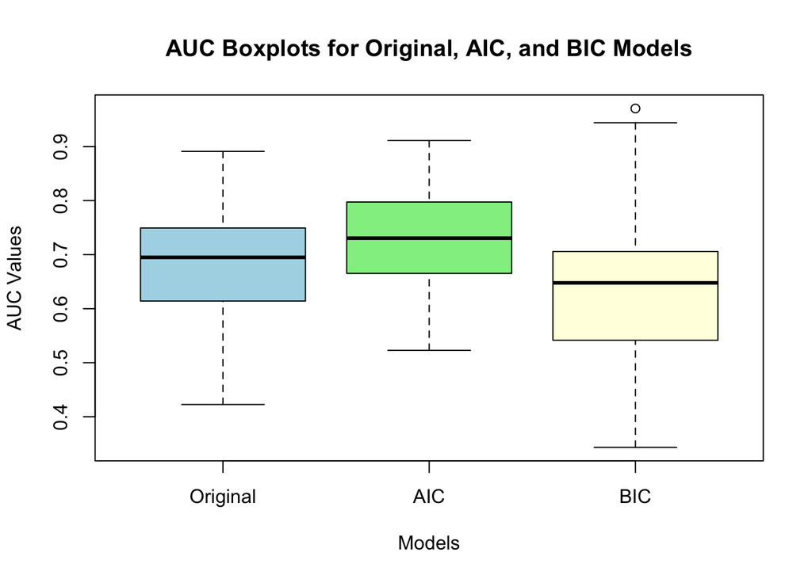

```r
# 绘制AUC箱线图
boxplot(auc_values,
        main = "AUC Boxplots for Original, AIC, and BIC Models",
        xlab = "Models",
        ylab = "AUC Values",
        col = c("lightblue", "lightgreen", "lightyellow"),
        names = c("Original", "AIC", "BIC"))
```

```r
# 打印平均AUC值
cat("\nAverage AUC Values:\n")
```

```
##
## Average AUC Values:
```

```r
sapply(auc_values, mean)
```

```
##  original       AIC       BIC
## 0.6797124 0.7269889 0.6373853
```